# Traits of the Most Popular Songs in 2018

Ysabella Atehortua and Ryan Kim

## Introduction

With over 158 million users worldwide, Spotify has become one of the most innovative companies in the music industry. Through their tailoring of playlists “For You,” recommending music they know you’ll love, and creating charts for pop music worldwide – Spotify has shown that they have a wealth of analytical data.

Because music is an important part of our daily lives, we wanted to explore the music world and find out what makes an artist or song popular. Using a dataset “Top Spotify Tracks of 2018” that looks at songs, artists, genres, and specific traits from Kaggle, we will look at the specific traits that the top songs on this list share. This data set was curated straight from Spotify’s API and has been collated to emphasize variables such as energy, loudness, key, and danceability. Analyzing this data set will not only allow us to see what artists dominated in 2018, but can show trends about what genres, keys, and aspects appeal to most listeners.

## Top Artists

The graph below showcases the number of times top artists were featured on Spotify’s Top 100 list in 2018. The most interesting aspect is the clear favorability of rap music during this time, with XXXTentacion, Post Malone, and Drake holding the top 3 spots in the chart. The chart also shows that pop artists (Selena Gomez, Camila Cabello), despite the genre name, are equally as popular as artists in genres such as Rap (Migos) and Alternative (Clean Bandit). It seems that the artists on this list may have less to do with the quality, but their streaming numbers which have many other confounding variables such as popularity with radio stations, the type of fans they appeal to, or viral songs. For example, Clean Bandit appeared on the chart an equal number of times as Kendrick Lamar and Ariana Grande, two artists with far more name recognition, however maybe due to their international appeal or those that were featured on their most popular songs, they are statistically ranked equally.

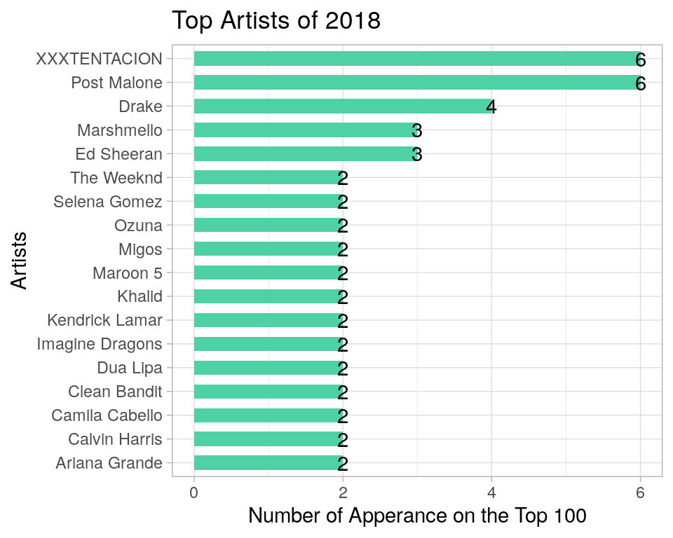

```r
top_artists <- spotify_data %>%
    group_by(artists)  %>%
    summarise(n_apperance = n()) %>%
    filter(n_apperance > 1) %>% # only show artists who appeared more than once
    arrange(desc(n_apperance))

#turn to categorical so we can reorder them using factor
top_artists$artists <- factor(top_artists$artists, levels = top_artists$artists[order(top_artists$n_apperance)]) # put in descending order

ggplot(top_artists, aes(x = artists, y = n_apperance)) +
    geom_bar(stat = "identity",  fill = "#4fd1a6", width = 0.6 ) +
    labs(title = "Top Artists of 2018", x = "Artists", y = "Number of Apperance on the Top 100") + theme_light() +
    geom_text(aes(label=n_apperance)) +
    coord_flip() #flip horizontally to see all the names
```

## Variable Correlation

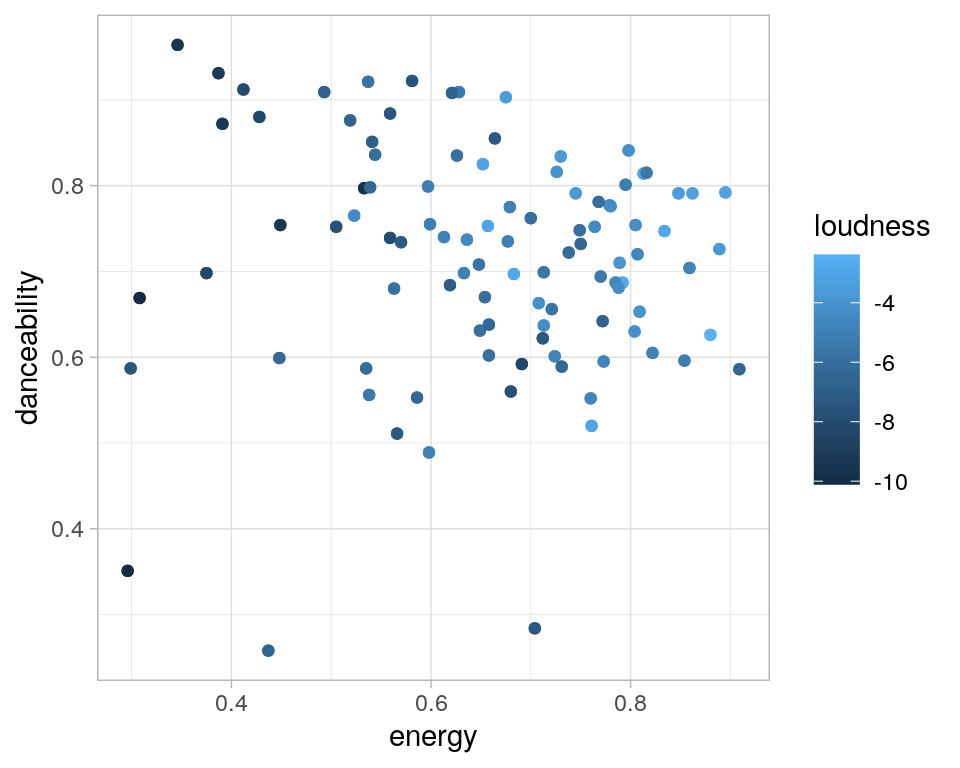

```r
base_plot <-
  spotify_data %>%
  ggplot(aes(y = danceability, x = energy)) + geom_point() +
  aes(color = loudness) +
  geom_point() +
theme_light()

base_plot
```

## Most Popular Key for Top Songs

The graph below shows the most common keys on Spotify’s Top 100 list, sorted by popularity. The graph shows that C#, D♭is the most popular and D#,E♭is the least popular. We can see the distribution of all the keys in the Top 100 and can easily see that songs in the key C♯,D♭ where wildly more popular than others. This key transcended genre as it was used by rap artists such as Drake and alternative artists such as Portugal. The Man. The disparity between this key and the rest lead to the conclusion that this a song in this key would likely be more popular than others.

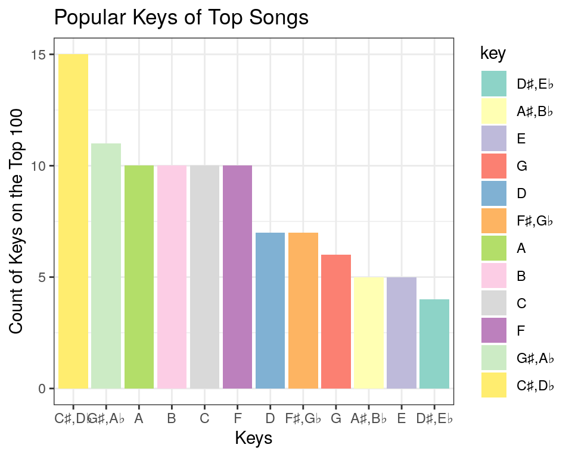

```r
spotify_data$key <- as.character(spotify_data$key) #change to categorical
spotify_data$key <- revalue(spotify_data$key, c("0" = "C", "1" = "C♯,D♭", "2" = "D", "3" = "D♯,E♭", "4" = "E", "5" =  "F", "6" = "F♯,G♭","7" = "G","8" = "G♯,A♭","9" = "A","10" = "A♯,B♭","11" = "B"))

song_keys <- spotify_data %>%
    group_by(key) %>%
    summarise(n_key = n()) %>%
    arrange(desc(n_key))

song_keys$key <- factor(song_keys$key, levels = song_keys$key[order(song_keys$n_key)]) # in order to visualise the keys in descending order

library(RColorBrewer)

ggplot(song_keys, aes(x = reorder(key,-n_key), y = n_key, fill = key)) +
    geom_bar(stat = "identity") +
    labs(title = "Popular Keys of Top Songs", x = "Keys", y = "Count of Keys on the Top 100") +
    theme_bw() +
    scale_fill_brewer(palette = "Set3")
```

## Discussion

Some questions that remained unanswered are whether this trend continues in more recent years and whether a song’s appearance on the Top 100 list correlates with the number of plays the song got. Questions also remain about popularity of the keys present in top songs. Because we cannot discern whether the song is in a major key or not, not much can be said about what makes these keys more popular than others (aside from coincidence).

## Appendix: Methodology

For Figure 1, we chose to display this as a bar graph because it is the most logical way for readers to be able to see the most popular artists. Because each bar is labelled and the graph is in descending order, it clearly shows the disparities and achievements of the top artists. We chose to limit the number of artists presented, showing only those that made it on the list more than once, to make the graphic more digestible and to discern artists as consistantly popular from “one-hit-wonders”.

For figure 3 we again used a bar graph to make it easy for readers to discern which keys were the most popular. We coded with color as well for purely aesthetic purposes and worked to reorder the plot in descending order to make comparisons between keys easier.